# The Shift in Major League Baseball

In Major League Baseball, the shift recently made news as the MLB announced it will be banned starting in the 2023 season. Typically when playing defense in baseball, each team has two infielders to the left of second base (third baseman and shortstop) and two infielders to the right of second base (second baseman and first baseman). But in recent years teams began to utilize shifts, bringing three or even four defenders to one side of second base. Teams were able to look at where the hitters they are facing typically hit the ball, and position their defense in the best spots to take away as many hits as possible. While many people viewed this as strategy and a new pa]rt of Major League baseball, the MLB evidently disagreed as they are bringing forward a ban that will force teams to keep two defenders on each side of second base. The main question that we will be focused on answering is how effective was the shift in taking away hits? Additionally we will look at how usage of the shift has changed over time, which teams are best at using the shift along with some other interesting analysis.

### The Data

The data that we will be using is from FanGraphs. FanGraphs is a massive database that has information on every baseball stat immaginable. The three main data frames that we be using using are shiftIP (data when the shift was active from 2012-2022), allIP (data from when the shift was both active and not active from 2012-2022), and lastly noShiftIP (data from when the shift was not active from 2012-2022). The years 2012-2022 were chosen as the shift was not used very frequently before the last 10 years.

### Data Analysis and Visualization

The first analysis that we will be doing is illustrating how the usage of the shift has changed over time. We will do this by plotting the average number of innings where the defense was shifted each year from 2012-2022.

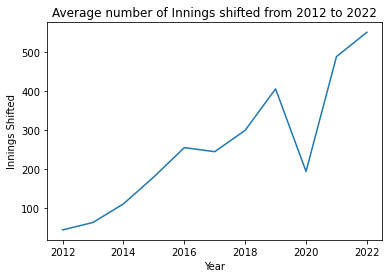

```python
import pandas as pd
shiftIP = pd.read_csv("2012-2022SHIFT_Adv.csv")
#This gives the amount of innings pitched by each team in which their defense was
#deployed in a traditional or untraditional shift from 2012 - 2022 (the past 10 years)
shiftIP.rename(columns = {'IP':'IP_shift'}, inplace = True)
#More data from 2012 with additional stats that we will need for later
shift_Standard = pd.read_csv("2012-2022SHIFT_Standard.csv")
shift_Standard = shift_Standard[["Season", "Tm", "H", "R", "ER", "OBP", "SLG", "HR", "SO"]]
shift_Standard["OPS"] = shift_Standard["SLG"] + shift_Standard["OBP"]
shiftIP = pd.merge(shiftIP, shift_Standard, on=["Season", "Tm"])

shiftchange = shiftIP.groupby("Season")["IP_shift"].mean()
shiftchange.plot(title = "Average number of Innings shifted from 2012 to 2022", xlabel = "Year", ylabel = "Innings Shifted")
```

As we can see the year 2020 is an outlier due to covid (teams only played 60 games rather than the usual 162), so we need to get the percentage of innings shifted instead of total innings shifted. Additionally even in noraml years, not every team plays the same amount of innings (due to extra innings and new 7 inning double headers that started the past two years), so a percentage is a much better metric.

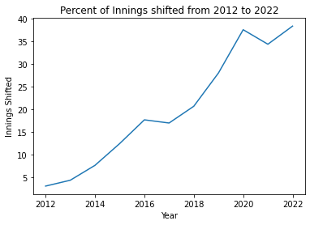

```python
allIP = pd.read_csv("2012-2022ALL_Adv.csv")
allIP.rename(columns = {'IP':'IP_total'}, inplace = True)
#More data from 2012 with additional stats that we will need for later
allIP_Standard = pd.read_csv("2012-2022ALL_Standard.csv")
allIP_Standard = allIP_Standard[["Season", "Tm", "H", "R", "ER", "OBP", "SLG", "HR", 'SO']]
allIP_Standard["OPS"] = allIP_Standard["SLG"] + allIP_Standard["OBP"]
allIP = pd.merge(allIP, allIP_Standard, on=["Season", "Tm"])

shiftIP = pd.merge(shiftIP, allIP[["Season", "Tm", "IP_total"]], on=["Season", "Tm"])
shiftIP["%shifted"] = shiftIP["IP_shift"] / shiftIP["IP_total"] * 100

shiftPercentChange = shiftIP.groupby("Season")["%shifted"].mean()
shiftPercentChange.plot(title = "Percent of Innings shifted from 2012 to 2022", xlabel = "Year", ylabel = "Innings Shifted")
```

As we can now see, from 2012-2022 there has been a clear increase of innings that MLB teams are deploying a shift.

### BABIP

An extremely important stat that we will be using throughout this project is BABIP. BABIP stands for Batting Average on Balls In Play. This metric is very useful for anaylizing the shift as the shift can only affect balls that are hit in play (the shift has no effect on events such as strike outs or homeruns).

In this secton we will be anaylizing how the league average BABIP has changed over time. Through this exploration we should be able to determine if there is a relationship between BABIP and the increasing use of the shift.

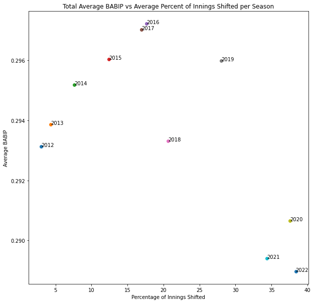

```python
import matplotlib.pyplot as plt
years = [2012, 2013, 2014, 2015, 2016, 2017, 2018, 2019, 2020, 2021, 2022]
avg_babip = allIP.groupby("Season")["BABIP"].mean()
p_shift = shiftIP.groupby("Season")["%shifted"].mean()

fig = plt.figure()
fig.set_figheight(10)
fig.set_figwidth(10)
counter = 0
for i in range(2012, 2023):
    plt.scatter(p_shift[i], avg_babip[i], label = i)
    plt.text(p_shift[i], avg_babip[i], s = i)
    counter = counter + 1

plt.title("Total Average BABIP vs Average Percent of Innings Shifted per Season")
plt.xlabel("Percentage of Innings Shifted")
plt.ylabel("Average BABIP")
plt.show()
```

This graph, does seem to show that as shifts become more and more frequent, BABIP has decreased, especially in recent years. But if you take a look at the Y axis, you can see that it has not changed by much. From the peak in 2016 to the low in 2022, BABIP appears to have only decreased by roughly .010 points. This means that a batter who hit a ball in play in 2022 got out just about 1% more than a batter who hit a ball in play in 2016. All in all this number does not seem very significant.

We can employ linear regression to see if there is a notable trend, and try to predict how Average BABIP and the percentage of innings shifted in the MLB will change in the coming years. By breaking the above graph into two different subplots, we can predict both how the percentage of innings shifted will change over the next five years, and how league average BABIP will change over the next five years.

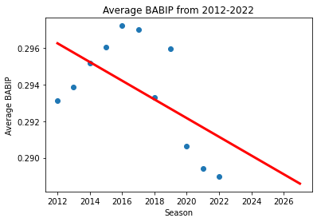

```python
y1 = avg_babip.array
x1 = [2012, 2013, 2014, 2015, 2016, 2017, 2018, 2019, 2020, 2021, 2022]

model = np.polyfit(x1, y1, 1)
predict = np.poly1d(model)
x_lin_reg = range(2012, 2028)
y_lin_reg = predict(x_lin_reg)

plt.scatter(x1, y1)
plt.plot(x_lin_reg, y_lin_reg, c = "r", linewidth = 3)
plt.title("Average BABIP from 2012-2022")
plt.xlabel("Season")
plt.ylabel("Average BABIP")
plt.show()
```

This graph shows a linear relationship that as Season increases, average BABIP decreases. The fit of the regression line is far from perfect though, it is clear the relationship is not perfect. Additionally through our regression line we can see that over the next five years, our model does not predict average BABIP will dip too far below the 2022 value.

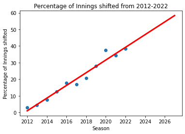

```python
import numpy as np
y2 = p_shift.array
x2 = [2012, 2013, 2014, 2015, 2016, 2017, 2018, 2019, 2020, 2021, 2022]

model = np.polyfit(x2, y2, 1)
predict = np.poly1d(model)
x_lin_reg = range(2012, 2028)
y_lin_reg = predict(x_lin_reg)

plt.scatter(x2, y2)
plt.plot(x_lin_reg, y_lin_reg, c = "r", linewidth = 3)
plt.title("Percentage of Innings shifted from 2012-2022")
plt.xlabel("Season")
plt.ylabel("Percentage of Innings shifted")
plt.show()
```

This graph has a much better fit as the linear relationship is clear, as Season increases, the percentage of innings shifted increases as well. Through this graph we can see that the model predicts over the next 5 years the average percentage of innings shifted in the MLB will continue to climb, reaching almost 60% in 2027.

While these graphs seem to show a general relationship between increasing innings shifted and decreasing BABIP, we do not have very many data points as we are only looking at seasonal averages since 2012. By look at each team individually from 2012 to 2022 we can see better see the effect increasing percentage of innings shifted has on BABIP.

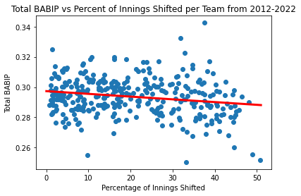

```python
plt.scatter(shiftIP["%shifted"], allIP["BABIP"])
plt.title("Total BABIP vs Percent of Innings Shifted per Team from 2012-2022")
plt.xlabel("Percentage of Innings Shifted")
plt.ylabel("Total BABIP")

model = np.polyfit(shiftIP["%shifted"], allIP["BABIP"], 1)
predict = np.poly1d(model)
x_lin_reg = range(0, 52)
y_lin_reg = predict(x_lin_reg)
plt.plot(x_lin_reg, y_lin_reg, c = "r", linewidth = 3)

plt.show()
```

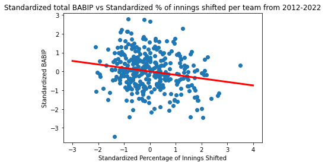

```python
for i, row in shiftIP.iterrows():
    shiftIP.at[i, "Standardized %shifted"] = (shiftIP.at[i, "%shifted"] - shiftIP.groupby("Season")["%shifted"].mean()[shiftIP.at[i, "Season"]]) / shiftIP.groupby("Season")["%shifted"].agg(np.std)[shiftIP.at[i, "Season"]]

for i, row in allIP.iterrows():
    allIP.at[i, "Standardized BABIP"] = (allIP.at[i, "BABIP"] - allIP.groupby("Season")["BABIP"].mean()[allIP.at[i, "Season"]]) / allIP.groupby("Season")["BABIP"].agg(np.std)[allIP.at[i, "Season"]]

plt.scatter(shiftIP["Standardized %shifted"], allIP["Standardized BABIP"])
plt.title("Standardized total BABIP vs Standardized % of innings shifted per team from 2012-2022")
plt.xlabel("Standardized Percentage of Innings Shifted")
plt.ylabel("Standardized BABIP")

model = np.polyfit(shiftIP["Standardized %shifted"], allIP["Standardized BABIP"], 1)
predict = np.poly1d(model)
x_lin_reg = range(-3, 5)
y_lin_reg = predict(x_lin_reg)
plt.plot(x_lin_reg, y_lin_reg, c = "r", linewidth = 3)

plt.show()
```

Going back to the Total Average BABIP vs Average Percent of Innings Shifted per Season graph, we can see that BABIP over the past 3 years, has been clearly trending down. Could this be because as teams are shifting more and more, they are becoming better at it? We can answer this question by looking at the average BABIP when shifted for each season.

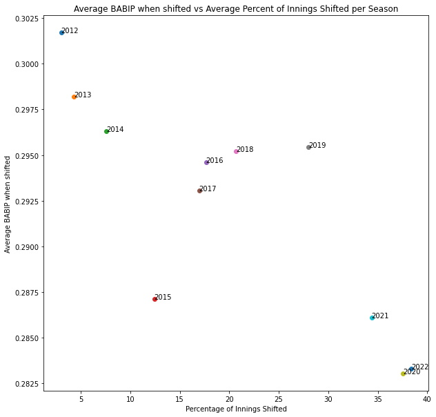

```python
years = [2012, 2013, 2014, 2015, 2016, 2017, 2018, 2019, 2020, 2021, 2022]
avg_babip = shiftIP.groupby("Season")["BABIP"].mean()
p_shift = shiftIP.groupby("Season")["%shifted"].mean()
fig = plt.figure()
fig.set_figheight(10)
fig.set_figwidth(10)

for i in range(2012, 2023):
    plt.scatter(p_shift[i], avg_babip[i], label = i)
    plt.text(p_shift[i], avg_babip[i], s = i)
    counter = counter + 1

plt.title("Average BABIP when shifted vs Average Percent of Innings Shifted per Season")
plt.xlabel("Percentage of Innings Shifted")
plt.ylabel("Average BABIP when shifted")
plt.show()
```

This graph has a much clearer linear relationship than our last as it shows that as teams shift more and more they are becoming better at taking away hits on balls in play.

### 2022 Teams

Now we know teams are getting better at effectivley deploying the shift, we will look at specific teams in 2022 to see if any teams stand out as being the best at shifting. We will do this by ploting the BABIP when shifted and percentage of inning shifted of each team in 2022.

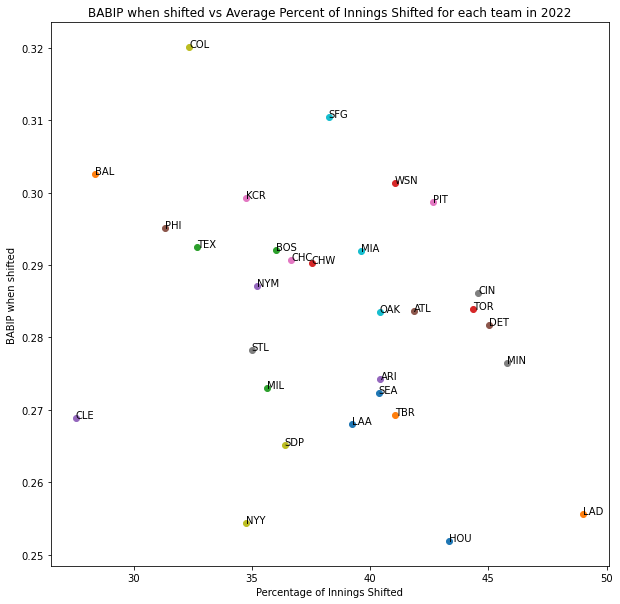

```python
shiftIP2022 = shiftIP[(allIP["Season"] == 2022)]
babip_team2022 = shiftIP2022[["Tm", "Season", "BABIP", "IP_total"]]
babip_team2022.rename(columns = {'BABIP':'BABIP_SHIFT'}, inplace = True)

babip_team2022 = pd.merge(babip_team2022, shiftIP[["Season", "Tm", "IP_shift"]], on=["Season", "Tm"])
babip_team2022["%shifted"] = babip_team2022["IP_shift"] / babip_team2022["IP_total"] * 100
#print(babip_team2022)

fig = plt.figure()
fig.set_figheight(10)
fig.set_figwidth(10)

for i in range(0, 30):
    plt.scatter(babip_team2022["%shifted"][i], babip_team2022["BABIP_SHIFT"][i], label = babip_team2022["Tm"][i])
    plt.text(babip_team2022["%shifted"][i], babip_team2022["BABIP_SHIFT"][i], s = babip_team2022["Tm"][i])

plt.title("BABIP when shifted vs Average Percent of Innings Shifted for each team in 2022")
plt.xlabel("Percentage of Innings Shifted")
plt.ylabel("BABIP when shifted")
plt.show()
```

While this graph seems to show us what teams have the lowest BABIP when shifted and therefore the best teams at using the shift, there is a big problem. This plot does not account for how good a teams pitching is in general. A team could just have very good pitching leading to lots of softly hit balls that are easy outs. For example in this graph it appears that the Yankees (NYY), Astros (HOU), and Dodgers (LAD) are the best at shifting as their BABIP when shifted is the lowest. But those teams might simply have very low BABIP in general, which would lead to this data being skewed. In order to tell if shifting is making a difference, we need to factor in BABIP when the team is not shifting. We will do this below by creating an expected BABIP value for each team (BABIP when not shifting - BABIP when shifting).

```python
#Now we will create a new data set from 2012-2022 without shifts
noShiftIP = pd.read_csv("2012-2022NoSHIFT_Adv.csv")
#This gives the amount of innings pitched by each team in which their defense was
#deployed in a traditional or untraditional shift from 2012 - 2022 (the past 10 years)
noShiftIP.rename(columns = {'IP':'IP_noShift'}, inplace = True)
#More data from 2012 with additional stats that we will need for later
noShift_Standard = pd.read_csv("2012-2022NoSHIFT_Standard.csv")
noShift_Standard = noShift_Standard[["Season", "Tm", "H", "R", "ER", "OBP", "SLG"]]
noShift_Standard["OPS"] = noShift_Standard["SLG"] + noShift_Standard["OBP"]
noShiftIP = pd.merge(noShiftIP, noShift_Standard, on=["Season", "Tm"])

babip_team2022 = pd.merge(babip_team2022, noShiftIP[["Season", "Tm", "IP_noShift", "BABIP"]], on=["Season", "Tm"])
babip_team2022.rename(columns = {'BABIP':'BABIP_noSHIFT'}, inplace = True)
#need to add BABIP
```

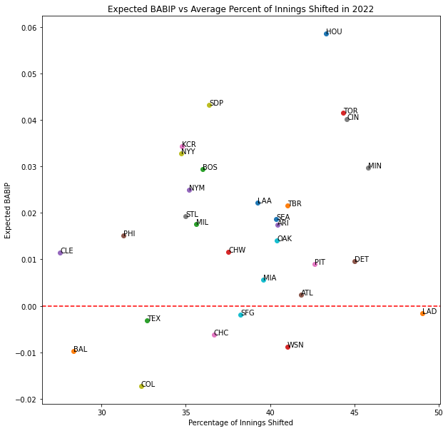

```python
babip_team2022["BABIP_change"] = babip_team2022["BABIP_noSHIFT"] - babip_team2022["BABIP_SHIFT"]

fig = plt.figure()
fig.set_figheight(10)
fig.set_figwidth(10)

for i in range(0, 30):
    plt.scatter(babip_team2022["%shifted"][i], babip_team2022["BABIP_change"][i], label = babip_team2022["Tm"][i])
    plt.text(babip_team2022["%shifted"][i], babip_team2022["BABIP_change"][i], s = babip_team2022["Tm"][i])

plt.title("Expected BABIP vs Average Percent of Innings Shifted in 2022")
plt.xlabel("Percentage of Innings Shifted")
plt.ylabel("Expected BABIP")
plt.axhline(y = 0.0, color = 'r', linestyle = 'dashed')
plt.show()
```

This graph shows how well teams shifts preformed in comparision to their non shifted defense. An expected BABIP value of 0 means that when shifted, the teams BABIP was the exact same was when not shifted. A positive value of Expected BABIP means that when shifted a team held opposing teams to a lower BABIP than when not shifted, showing the shift worked. For example in this graph the Astros (HOU) are listed at .06. this means that when their defense was in a shift, the opposing team's BABIP was 6% lower than when they were not in a shift. This graph shows which teams are good at deploying the shift, versus which teams just had good pitching. While the previous graph made it seem that the Dodgers (LAD) were the best at shifting, through this graph we can see that was simply due to their great pitching. Their expected BABIP on this graph is 0.00 meaning their BABIP was the same when shifting vs. not shifting. Through this graph we can see that the vast majority of teams gave up less hits when in the shift, as the majority of them are above the 0.00 line.

### Conclusion:

After analyizing the shift, it appears that it has not had as big of an effect on baseball as most people think. Usage of the shift has been on a clear upward trend over the past 10 years. Over this time there has been a decrease in BABIP, but not to an extreme or even moderate level. Over these past 10 years there is a slight relationship showing that teams who shift more are more likley to have a lower BABIP than teams that shift less, but again the relationship is not very strong. What is clear is that over time teams are becoming better at the shift, and certain teams are able to use the shift more to their advantage than others.

While these small changes in BABIP and the advantage that some teams have been able to gain might contribute to the MLB's decision to ban the shift, the ban seems to be more of a preventative measure. Baseball is a game that is heavily rooted in traditions and the shift was changing the basics of the game. Without a ban on the shift, in the near future defenses could end up playing in shifts for more than half of the total innings in a season. By banning the shift, I believe that the MLB is showing their focus on upholding the traditions of baseball.